# Tugas Praktikum

## Tugas

1. Setiap kelompok memilih satu data time series dengan panjang ≥ 500 periode.
2. Data dibagi rata ke setiap anggota; minimal 100 observasi per orang.
3. Terapkan metode pemulusan yang sudah dipelajari (SMA, DMA, SES, DES, atau Holt-Winters) pada bagian data masing-masing
4. Bandingkan kinerja metode dan tentukan metode terbaik untuk data tersebut menggunakan metrik akurasi (mis. SSE/MSE/RMSE/MAPE), lalu jelaskan alasannya secara singkat.

   Upload tugas per individu ke GitHub pada folder `Pertemuan-2` dengan format HTML bernama `Tugas-Pertemuan-2.html`.

## 1. Preparation & Library Loading

Langkah awal adalah memanggil packages yang dibutuhkan untuk analisis pemulusan deret waktu (time series smoothing).

```r
library(rio)        # Untuk impor data (CSV, XLSX, dll)
library(forecast)   # Untuk fungsi pemulusan SES, DES, & Holt-Winters
library(TTR)        # Untuk fungsi Moving Average (SMA/DMA)
```

```r
library(ggplot2)    # Untuk visualisasi interaktif & rapi
library(knitr)      # Untuk pembuatan tabel ringkas
```

## 2. Impor & Pemrosesan Data

```r
# 1. Impor File Data
data_raw <- import("^JKSE_historis.csv")

# 2. Bagi data menjadi 5 bagian dan ambil bagian ke-2
total_n   <- nrow(data_raw)
start_idx <- floor(1 * total_n / 5) + 1  # Mulai baris ke-240
end_idx   <- floor(2 * total_n / 5)      # Sampai baris ke-479

# Slicing data khusus bagian ke-2 (sekitar 240 observasi)
data_bagian2 <- data_raw[start_idx:end_idx, ]

# 3. Ambil variabel harga target (sesuaikan kolom: Close / Terakhir)
y_vec <- data_bagian2$Close

# 4. Ubah ke format deret waktu (ts)
data_ts <- ts(y_vec)

# 5. Informasi data bagian ke-2
cat("Rentang Baris Data :", start_idx, "s/d", end_idx, "\n")
```

```
## Rentang Baris Data : 240 s/d 479
```

```r
cat("Total Observasi    :", length(y_vec), "data\n")
```

```
## Total Observasi    : 240 data
```

```r
head(data_bagian2)
```

```
##                    Date     Open     High      Low    Close    Volume Dividends
## 240 2022-08-18 17:00:00 7186.598 7230.111 7172.434 7172.434 232876500         0
## 241 2022-08-21 17:00:00 7172.434 7174.283 7064.501 7107.983 204493100         0
## 242 2022-08-22 17:00:00 7107.863 7183.259 7106.835 7163.265 260557700         0
## 243 2022-08-23 17:00:00 7163.305 7204.420 7154.644 7194.706 221550000         0
## 244 2022-08-24 17:00:00 7194.706 7210.163 7146.312 7174.208 280881500         0
## 245 2022-08-25 17:00:00 7174.288 7194.081 7135.248 7135.248 273878800         0
##     Stock Splits
## 240            0
## 241            0
## 242            0
## 243            0
## 244            0
## 245            0
```

## 3. Eksplorasi Data Deret Waktu

Melihat ringkasan statistik dan pola visual keseluruhan data historis.

```r
# Ringkasan Statistik
summary(data_ts)
```

```
##    Min. 1st Qu.  Median    Mean 3rd Qu.    Max.
##    6566    6767    6859    6884    7018    7318
```

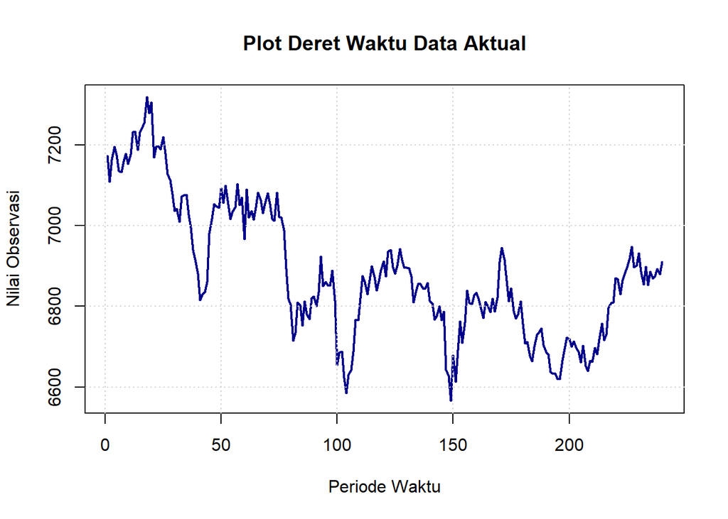

```r
# Plot Utama Deret Waktu
plot(data_ts, col = "darkblue", lwd = 2,
     main = "Plot Deret Waktu Data Aktual",
     xlab = "Periode Waktu", ylab = "Nilai Observasi")
grid()
```

## 4. Pembagian Data Train & Test (80:20)

Pembagian dilakukan secara dinamis berdasarkan proporsi 80% data latih (training) dan 20% data uji (testing).

```r
n <- length(data_ts)
n_train <- floor(0.8 * n)
n_test <- n - n_train

# Membagi data vektor
train_data <- y_vec[1:n_train]
test_data  <- y_vec[(n_train + 1):n]

# Membagi format Time Series
train_ts <- ts(train_data)
test_ts  <- ts(test_data)

cat("Jumlah Total Data  :", n, "\n")
```

```
## Jumlah Total Data  : 240
```

```r
cat("Jumlah Data Latih  :", n_train, "\n")
```

```
## Jumlah Data Latih  : 192
```

```r
cat("Jumlah Data Uji    :", n_test, "\n")
```

```
## Jumlah Data Uji    : 48
```

## 5. Pemodelan & Pemulusan (Smoothing)

Berikut adalah penerapan 4 metode pemulusan utama pada data latih:

### 5.1 Single Moving Average (SMA) — $m = 4$Metode ini cocok untuk data dengan pola stasioner (tanpa tren tajam atau musiman).

```r
m <- 4
sma_fit <- SMA(train_ts, n = m)

# Ramalan h-langkah ke depan untuk data uji (konstan sebesar nilai pemulusan terakhir)
sma_forecast <- rep(tail(sma_fit[!is.na(sma_fit)], 1), n_test)
```

### 5.2 Double Moving Average (DMA) — $m = 4$Metode pemulusan dua kali yang efektif untuk menangkap tren linier sederhana.

```r
dma_1 <- SMA(train_ts, n = m)
dma_2 <- SMA(dma_1, n = m)

# Komponen Level (At) dan Tren (Bt)
At <- 2 * dma_1 - dma_2
Bt <- (2 / (m - 1)) * (dma_1 - dma_2)

# Ramalan h-langkah ke depan untuk data uji
h <- 1:n_test
last_At <- tail(At[!is.na(At)], 1)
last_Bt <- tail(Bt[!is.na(Bt)], 1)

dma_forecast <- last_At + (last_Bt * h)
```

### 5.3 Single Exponential Smoothing (SES) - Parameter OptimalSES memberikan bobot mengecil secara eksponensial pada pengamatan historis. Parameter $\alpha$ dioptimalkan secara otomatis.

```r
ses_opt <- HoltWinters(train_ts, beta = FALSE, gamma = FALSE)
ses_pred <- forecast(ses_opt, h = n_test)

ses_forecast <- as.numeric(ses_pred$mean)
```

### 5.4 Double Exponential Smoothing (DES) - Parameter Optimal

Metode Holt’s Exponential Smoothing merespons pola data yang memiliki tren.

```r
des_opt <- HoltWinters(train_ts, gamma = FALSE)
des_pred <- forecast(des_opt, h = n_test)

des_forecast <- as.numeric(des_pred$mean)
```

## 6. Visualisasi Hasil Peramalan pada Data Uji

Perbandingan visual antara nilai aktual data uji dengan hasil peramalan dari masing-masing metode pemulusan.

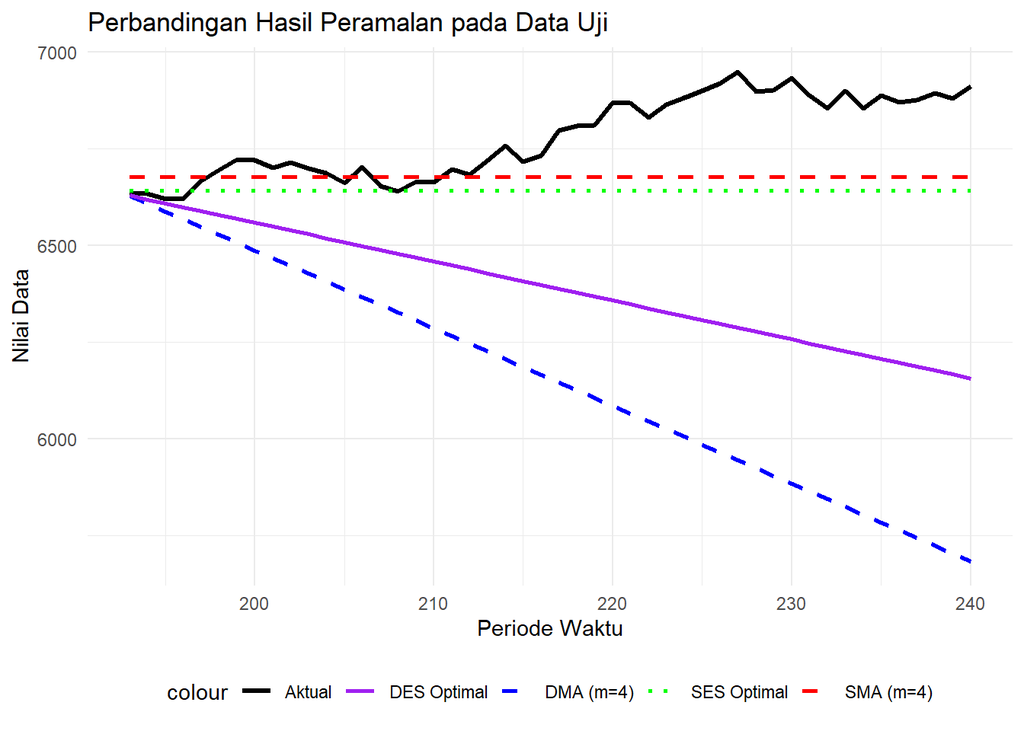

```r
df_plot <- data.frame(
  Periode = (n_train + 1):n,
  Aktual  = test_data,
  SMA     = sma_forecast,
  DMA     = dma_forecast,
  SES     = ses_forecast,
  DES     = des_forecast
)

ggplot(df_plot, aes(x = Periode)) +
  geom_line(aes(y = Aktual, color = "Aktual"), size = 1.2) +
  geom_line(aes(y = SMA, color = "SMA (m=4)"), linetype = "dashed", size = 0.9) +
  geom_line(aes(y = DMA, color = "DMA (m=4)"), linetype = "dashed", size = 0.9) +
  geom_line(aes(y = SES, color = "SES Optimal"), linetype = "dotted", size = 1) +
  geom_line(aes(y = DES, color = "DES Optimal"), linetype = "solid", size = 0.9) +
  labs(title = "Perbandingan Hasil Peramalan pada Data Uji",
       x = "Periode Waktu", y = "Nilai Data") +
  scale_color_manual(values = c("Aktual" = "black", "SMA (m=4)" = "red",
                                "DMA (m=4)" = "blue", "SES Optimal" = "green",
                                "DES Optimal" = "purple")) +
  theme_minimal() +
  theme(legend.position = "bottom")
```

## 7. Evaluasi Akurasi Pemodelan (Data Uji)

Fungsi evaluasi akurasi menggunakan Sum of Squared Errors (SSE), Mean Squared Error (MSE), Root Mean Squared Error (RMSE), dan Mean Absolute Percentage Error (MAPE).

```r
calc_metrics <- function(actual, forecast) {
  e <- actual - forecast
  sse  <- sum(e^2, na.rm = TRUE)
  mse  <- mean(e^2, na.rm = TRUE)
  rmse <- sqrt(mse)
  mape <- mean(abs(e / actual) * 100, na.rm = TRUE)
  return(c(SSE = sse, MSE = mse, RMSE = rmse, MAPE_Persen = mape))
}

# Perhitungan Metrik Evaluasi pada Data Uji
acc_sma <- calc_metrics(test_data, sma_forecast)
acc_dma <- calc_metrics(test_data, dma_forecast)
acc_ses <- calc_metrics(test_data, ses_forecast)
acc_des <- calc_metrics(test_data, des_forecast)

# Penyusunan Tabel Perbandingan Metrik Evaluasi
tabel_akurasi <- data.frame(
  Metode = c("Single Moving Average (SMA)",
             "Double Moving Average (DMA)",
             "Single Exponential Smoothing (SES)",
             "Double Exponential Smoothing (DES)"),
  rbind(acc_sma, acc_dma, acc_ses, acc_des)
)

kable(tabel_akurasi, digits = 4, caption = "Tabel Evaluasi Akurasi Peramalan Data Uji")
```

Tabel Evaluasi Akurasi Peramalan Data Uji

|  | Metode | SSE | MSE | RMSE | MAPE_Persen |
| --- | --- | --- | --- | --- | --- |
| acc_sma | Single Moving Average (SMA) | 1015477 | 21155.78 | 145.4503 | 1.6878 |
| acc_dma | Double Moving Average (DMA) | 25433932 | 529873.57 | 727.9242 | 9.1328 |
| acc_ses | Single Exponential Smoothing (SES) | 1446091 | 30126.90 | 173.5710 | 2.0684 |
| acc_des | Double Exponential Smoothing (DES) | 9893150 | 206107.29 | 453.9904 | 5.6632 |

## 8. Kesimpulan & Penjelasan Metode Terbaik

Berdasarkan hasil evaluasi kriteria keakuratan peramalan pada Data Uji (Testing Data), berikut adalah ringkasan performa masing-masing metode:

- Single Moving Average (SMA): MAPE = 1.69% | RMSE = 145.45
- Single Exponential Smoothing (SES): MAPE = 2.07% | RMSE = 173.57
- Double Exponential Smoothing (DES): MAPE = 5.66% | RMSE = 453.99
- Double Moving Average (DMA): MAPE = 9.13% | RMSE = 727.92

### Kesimpulan

Metode terbaik untuk memodelkan data ini adalah **Single Moving Average (SMA)** dengan nilai parameter $m = 4$. Metode ini menghasilkan tingkat kesalahan (error) terendah di seluruh metrik evaluasi pada data uji: * **SSE:** 1015477 * **MSE:** 21155.78 * **RMSE:** 145.45 * **MAPE:** 1.69%

Metode **Single Exponential Smoothing (SES)** memberikan hasil yang hampir setara dengan nilai MAPE sebesar 2.07%.